# Fullmer_Exam_3

christian

11/26/2019

## Exam 3

Some questions to answer: Which sample locations are functionally different from each other in terms of what C-substrates they can utilize?

Are Soil and Water samples significantly different overall (as in, overall diversity of usable carbon sources)? What about for individual carbon substrates? If there are differences between samples, which C-substrates are driving those differences? Does the dilution factor change any of these answers? Do the control samples indicate any contamination? Q:Is there a difference in light absorbance values at the same dilution and sample site across repetitions? i.e how good is our regression coefficent at each locationDilution Q: how much does dilution affect absorbance?

#Reading, cleaning, preliminary manipulation

Read-in using the “|” as the deliminating factor.

```r
biologTidy<- biologData %>%pivot_longer(cols=starts_with("Hr_"), names_to = "Hr",names_prefix = "Hr_", values_to = "Absorbance" )


#play with this to see differences in predictive power of models based on different data class
#having information on well and substrate is either redundant or here for some reason, but in either case it shuold be evaluated to see if there is a reason its here and if not the redundancy should be addressed in some way.
```

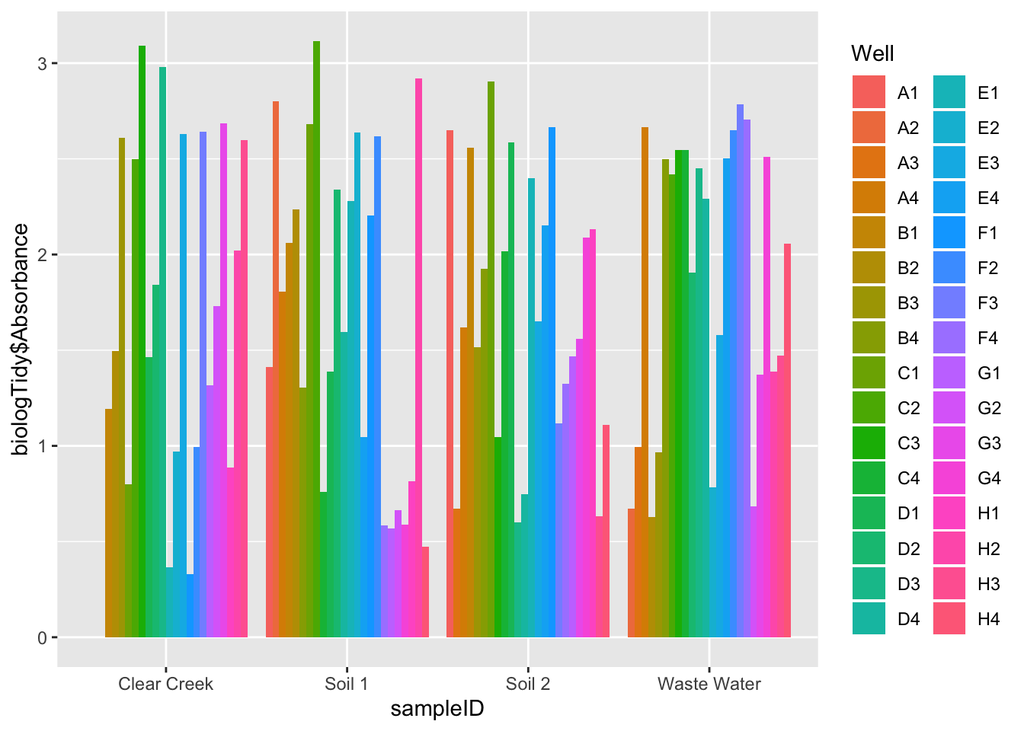

```r
biologClearCreek<- filter(biologTidy, Sample.ID=="Clear_Creek") %>% dplyr::select(-Sample.ID)
biologSoil1<- filter(biologTidy, Sample.ID=="Soil_1") %>% dplyr::select(-Sample.ID)
biologSoil2<- filter(biologTidy, Sample.ID=="Soil_2") %>% dplyr::select(-Sample.ID)
biologWasteWater<-filter(biologTidy, Sample.ID=="Waste_Water") %>% dplyr::select(-Sample.ID)



# create a dataset
sampleID <- c(rep("Clear Creek" , 3) , rep("Soil 1" , 3) , rep("Soil 2" , 3) , rep("Waste Water" , 3) )
Well<- rep(c("A1" , "A2" , "A3", "A4","B1" , "B2" , "B3", "B4","C1" , "C2" , "C3", "C4","D1" , "D2" , "D3", "D4","E1" , "E2" , "E3", "E4","F1" , "F2" , "F3", "F4","G1" , "G2" , "G3", "G4","H1" , "H2" , "H3", "H4") , 4)
data <- data.frame(sampleID,Well,biologTidy$Absorbance)


# Grouped
ggplot(data, aes(fill=Well, y=biologTidy$Absorbance, x=sampleID)) +
    geom_bar(position="dodge", stat="identity")
```

```r
#ClearCreek
canCC<-biologClearCreek%>%dplyr::filter(Absorbance_Sum>0)%>%dplyr::select(Well, Substrate)%>%unique()
canS1<-biologSoil1%>%dplyr::filter(Absorbance_Sum>0)%>%dplyr::select(Well, Substrate)%>%unique()
canS2<-biologSoil2%>%dplyr::filter(Absorbance_Sum>0)%>%dplyr::select(Well, Substrate)%>%unique()
canWW<-biologWasteWater%>%dplyr::filter(Absorbance_Sum>0)%>%dplyr::select(Well, Substrate)%>%unique()

#Index of Substrates and Well for substrates with non-zero value for Clear Creek Sample
canCC%>%group_by(Well)%>%print()
```

```
## # A tibble: 31 x 2
## # Groups:   Well [31]
##    Well  Substrate
##    <fct> <fct>
##  1 A2    β-Methyl-D- Glucoside
##  2 A3    D-Galactonic Acid γ-Lactone
##  3 A4    L-Arginine
##  4 B1    Pyruvic Acid Methyl Ester
##  5 B2    D-Xylose
##  6 B3    D-Galacturonic Acid
##  7 B4    L-Asparganine
##  8 C1    Tween 40
##  9 C2    i-Erythitol
## 10 C3    2-Hydroxy Benzoic Acid
## # … with 21 more rows
```

```r
#Index of Substrates and Well for substrates with non-zero value for Soil 1 Sample

canS1%>%group_by(Well)%>%print()
```

```
## # A tibble: 31 x 2
## # Groups:   Well [31]
##    Well  Substrate
##    <fct> <fct>
##  1 A2    β-Methyl-D- Glucoside
##  2 A3    D-Galactonic Acid γ-Lactone
##  3 A4    L-Arginine
##  4 B1    Pyruvic Acid Methyl Ester
##  5 B2    D-Xylose
##  6 B3    D-Galacturonic Acid
##  7 B4    L-Asparganine
##  8 C1    Tween 40
##  9 C2    i-Erythitol
## 10 C3    2-Hydroxy Benzoic Acid
## # … with 21 more rows
```

```r
#Index of Substrates and Well for substrates with non-zero value for Soil 2 Sample

canS2%>%group_by(Well)%>%print()
```

```
## # A tibble: 31 x 2
## # Groups:   Well [31]
##    Well  Substrate
##    <fct> <fct>
##  1 A2    β-Methyl-D- Glucoside
##  2 A3    D-Galactonic Acid γ-Lactone
##  3 A4    L-Arginine
##  4 B1    Pyruvic Acid Methyl Ester
##  5 B2    D-Xylose
##  6 B3    D-Galacturonic Acid
##  7 B4    L-Asparganine
##  8 C1    Tween 40
##  9 C2    i-Erythitol
## 10 C3    2-Hydroxy Benzoic Acid
## # … with 21 more rows
```

```r
#Index of Substrates and Well for substrates with non-zero value for WW Sample

canWW%>%group_by(Well)%>%print()
```

```
## # A tibble: 31 x 2
## # Groups:   Well [31]
##    Well  Substrate
##    <fct> <fct>
##  1 A3    D-Galactonic Acid γ-Lactone
##  2 A4    L-Arginine
##  3 B1    Pyruvic Acid Methyl Ester
##  4 B2    D-Xylose
##  5 B3    D-Galacturonic Acid
##  6 C1    Tween 40
##  7 C2    i-Erythitol
##  8 C4    L-Phenylalanine
##  9 D1    "Tween 80 "
## 10 D2    D-Mannitol
## # … with 21 more rows
```

```r
biologClearCreekVeryDilute <- filter(biologTidy, Sample.ID=="Clear_Creek", as.factor(Dilution)==.001) %>% dplyr::select(-Sample.ID, -Dilution)
biologClearCreekDilute <- filter(biologTidy, Sample.ID=="Clear_Creek", as.factor(Dilution)==.01) %>% dplyr::select(-Sample.ID, -Dilution)
biologClearCreekPotent <- filter(biologTidy, Sample.ID=="Clear_Creek", as.factor(Dilution)==.1) %>% dplyr::select(-Sample.ID, -Dilution)

biologSoil1VeryDilute<- filter(biologTidy, Sample.ID=="Soil_1", as.factor(Dilution)==.001) %>% dplyr::select(-Sample.ID, -Dilution)
biologSoil1Dilute<- filter(biologTidy, Sample.ID=="Soil_1", as.factor(Dilution)==.01) %>% dplyr::select(-Sample.ID, -Dilution)
biologSoil1Potent<- filter(biologTidy, Sample.ID=="Soil_1", as.factor(Dilution)==.1) %>% dplyr::select(-Sample.ID, -Dilution)
biologSoil2<- filter(biologTidy, Sample.ID=="Soil_2") %>% dplyr::select(-Sample.ID)
biologSoil2VeryDilute<- filter(biologTidy, Sample.ID=="Soil_2", as.factor(Dilution)==.001) %>% dplyr::select(-Sample.ID, -Dilution)
biologSoil2Dilute<- filter(biologTidy, Sample.ID=="Soil_2", as.factor(Dilution)==.01) %>% dplyr::select(-Sample.ID, -Dilution)
biologSoil2Potent<- filter(biologTidy, Sample.ID=="Soil_2", as.factor(Dilution)==.1) %>% dplyr::select(-Sample.ID, -Dilution)

biologWasteWaterVeryDilute<- filter(biologTidy, Sample.ID=="Waste_Water", as.factor(Dilution)==.001) %>% dplyr::select(-Sample.ID, -Dilution)
biologWasteWaterDilute<- filter(biologTidy, Sample.ID=="Waste_Water", as.factor(Dilution)==.01) %>% dplyr::select(-Sample.ID, -Dilution)
biologWasteWaterPotent<- filter(biologTidy, Sample.ID=="Waste_Water", as.factor(Dilution)==.1) %>% dplyr::select(-Sample.ID, -Dilution)
```

2. by location

cc = biologClearCreek%>% filter(Response==TRUE)%>%ggplot(., aes(x = Hr, y = Absorbance, color=Rep)) + geom_smooth(method=loess(degree = 2L))+geom_point(aes(shape=Dilution))+labs(title = “Absorbance vs Time at Clear Creek for Substrate:”)

plots = biologClearCreek %>% group_by(Substrate) %>% do(plots = cc %+% . + facet_wrap(~Substrate))

plots$plots

p <- ggplot(data = df, aes(x = x, y = y)) + geom_smooth(method = “lm”, se=FALSE, color=“black”, formula = y ~ x) + geom_point() p

p1 <- p + geom_text(x = 25, y = 300, label = lm_eqn(df), parse = TRUE)

soil1 = ggplot(data = biologSoil1, aes(x = Hr, y = Absorbance, color=Dilution)) + geom_smooth()+geom_point()

plots = biologSoil1 %>% group_by(Substrate) %>% do(plots = soil1 %+% . + facet_wrap(~Substrate))

plots$plots

soil2 = ggplot(data = biologSoil2, aes(x = Hr, y = Absorbance, color=Dilution)) + geom_smooth()+geom_point()

plots = biologSoil2 %>% group_by(Substrate) %>% do(plots = soil2 %+% . + facet_wrap(~Substrate))

plots$plots

ww = ggplot(data = biologWasteWater, aes(x = Hr, y = Absorbance, color=Dilution)) + geom_smooth()+geom_point()

plots = biologWasteWater %>% group_by(Substrate) %>% do(plots = ww %+% . + facet_wrap(~Substrate))

plots$plots

[output not shown]

##quantitartively exploring data a. Evaluating overarching models which include all data How do I avoid overfitting?

```r
#Mod1 doesnt include rep so comparing between this model and subsequent ones that do should give information regarding how much changes between reps, but ultimately, it shouldnt be used in the model, because repetitions are a control.


mod1_aov_biologTidy<-aov(Absorbance~Hr+Substrate+Sample.ID+Dilution,data=biologTidy)
summary.aov(mod1_aov_biologTidy)
```

```
##               Df Sum Sq Mean Sq F value   Pr(>F)
## Hr             2  332.8  166.40  597.87  < 2e-16 ***
## Substrate     31  143.0    4.61   16.58  < 2e-16 ***
## Sample.ID      3  244.0   81.34  292.26  < 2e-16 ***
## Dilution       1    4.7    4.65   16.71 4.46e-05 ***
## Residuals   3418  951.3    0.28
## ---
## Signif. codes:  0 '***' 0.001 '**' 0.01 '*' 0.05 '.' 0.1 ' ' 1
```

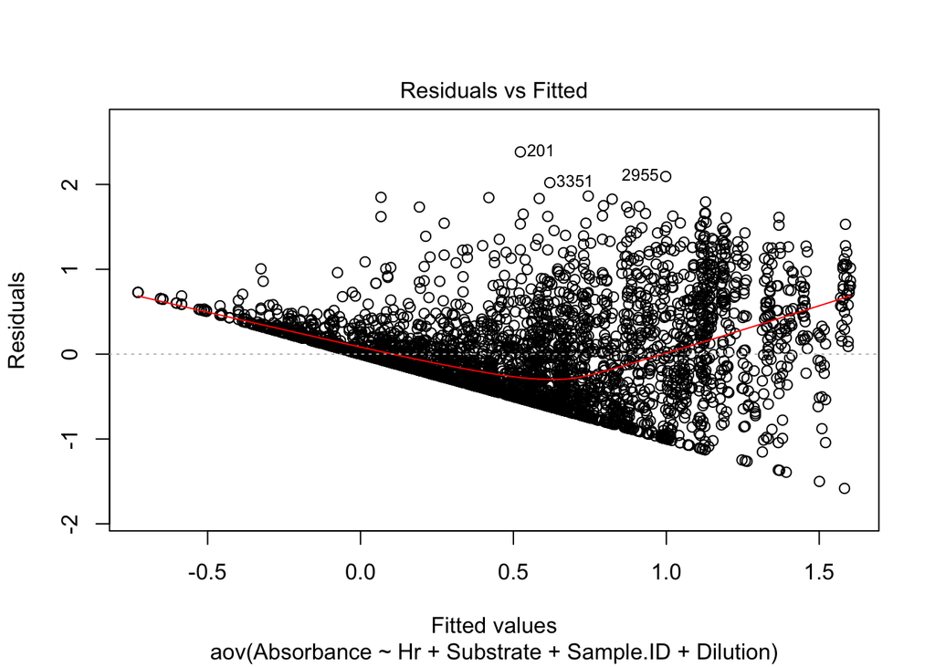

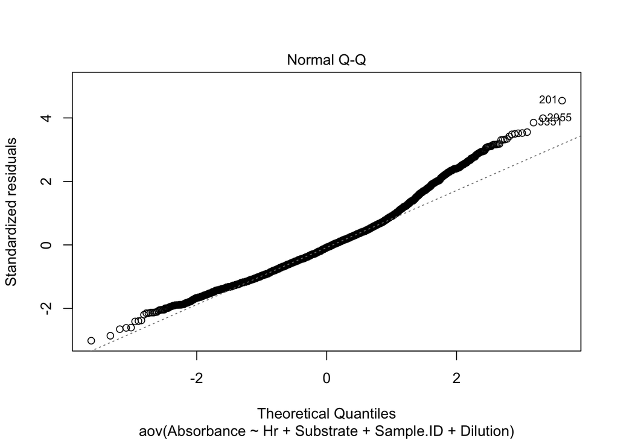

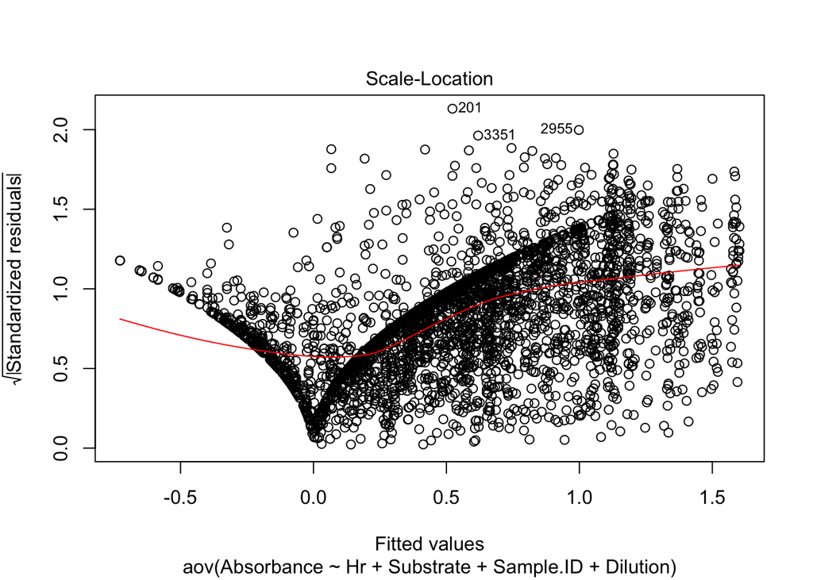

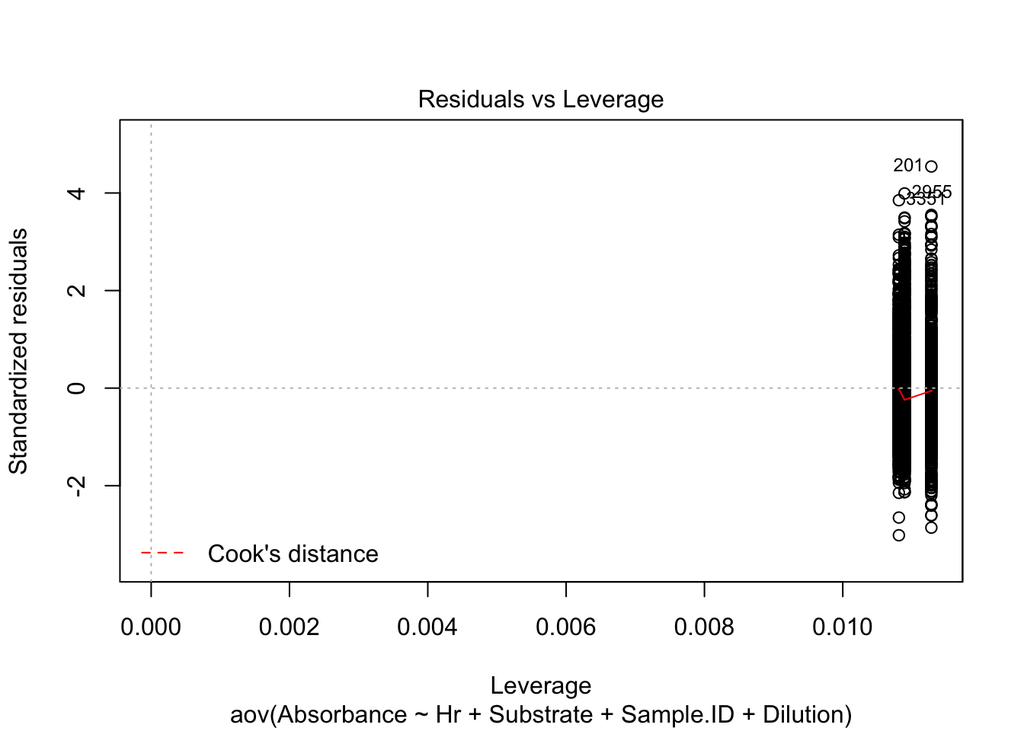

```r
plot(mod1_aov_biologTidy)
```

```r
mod2_aov_biologTidy<-aov(Absorbance~Hr*Substrate*Sample.ID*Dilution*Rep,data=biologTidy)
summary.aov(mod2_aov_biologTidy)
```

```
##                                       Df Sum Sq Mean Sq  F value   Pr(>F)
## Hr                                     2  332.8  166.40 1337.489  < 2e-16 ***
## Substrate                             31  143.0    4.61   37.081  < 2e-16 ***
## Sample.ID                              3  244.0   81.34  653.815  < 2e-16 ***
## Dilution                               1    4.7    4.65   37.379 1.18e-09 ***
## Rep                                    1    1.9    1.88   15.073 0.000107 ***
## Hr:Substrate                          62   71.8    1.16    9.307  < 2e-16 ***
## Hr:Sample.ID                           6   72.9   12.15   97.692  < 2e-16 ***
## Substrate:Sample.ID                   93   66.1    0.71    5.716  < 2e-16 ***
## Hr:Dilution                            2    4.0    1.98   15.948 1.35e-07 ***
## Substrate:Dilution                    31   13.4    0.43    3.485 4.09e-10 ***
## Sample.ID:Dilution                     3  100.2   33.41  268.553  < 2e-16 ***
## Hr:Rep                                 2    2.4    1.19    9.577 7.27e-05 ***
## Substrate:Rep                         31    6.1    0.20    1.586 0.021487 *
## Sample.ID:Rep                          3   49.4   16.46  132.270  < 2e-16 ***
## Dilution:Rep                           1    0.0    0.02    0.145 0.703219
## Hr:Substrate:Sample.ID               186   59.3    0.32    2.564  < 2e-16 ***
## Hr:Substrate:Dilution                 62   14.8    0.24    1.920 2.85e-05 ***
## Hr:Sample.ID:Dilution                  6   60.2   10.03   80.645  < 2e-16 ***
## Substrate:Sample.ID:Dilution          93   49.9    0.54    4.309  < 2e-16 ***
## Hr:Substrate:Rep                      62    6.4    0.10    0.835 0.816016
## Hr:Sample.ID:Rep                       6    3.1    0.52    4.166 0.000362 ***
## Substrate:Sample.ID:Rep               93   23.9    0.26    2.064 2.56e-08 ***
## Hr:Dilution:Rep                        2    1.1    0.56    4.490 0.011343 *
## Substrate:Dilution:Rep                31    3.9    0.13    1.018 0.439833
## Sample.ID:Dilution:Rep                 3    0.0    0.00    0.031 0.992639
## Hr:Substrate:Sample.ID:Dilution      186   33.5    0.18    1.446 0.000160 ***
## Hr:Substrate:Sample.ID:Rep           186   21.0    0.11    0.907 0.804849
## Hr:Substrate:Dilution:Rep             62    5.3    0.09    0.688 0.969598
## Hr:Sample.ID:Dilution:Rep              6    1.3    0.21    1.725 0.111344
## Substrate:Sample.ID:Dilution:Rep      93   23.4    0.25    2.023 6.51e-08 ***
## Hr:Substrate:Sample.ID:Dilution:Rep  186   17.0    0.09    0.737 0.996178
## Residuals                           1920  238.9    0.12
## ---
## Signif. codes:  0 '***' 0.001 '**' 0.01 '*' 0.05 '.' 0.1 ' ' 1
```

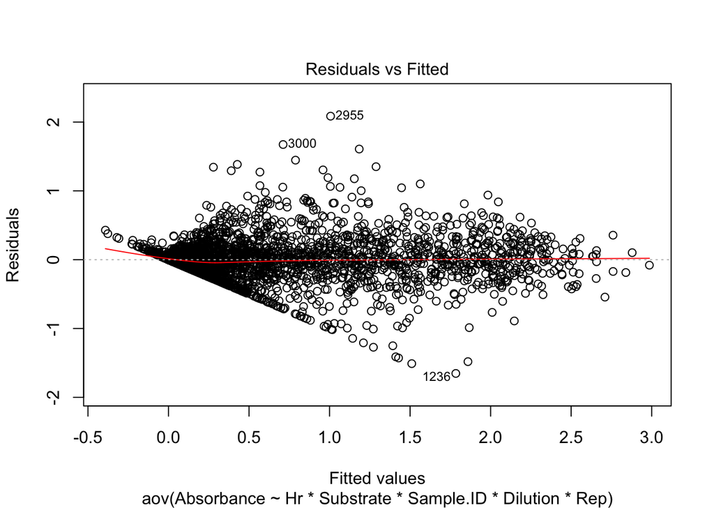

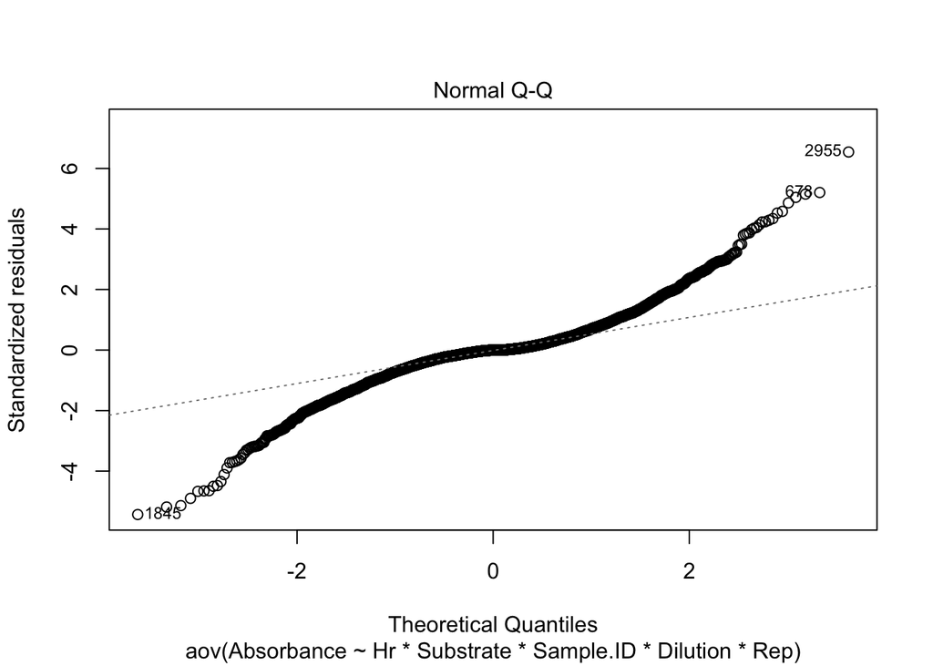

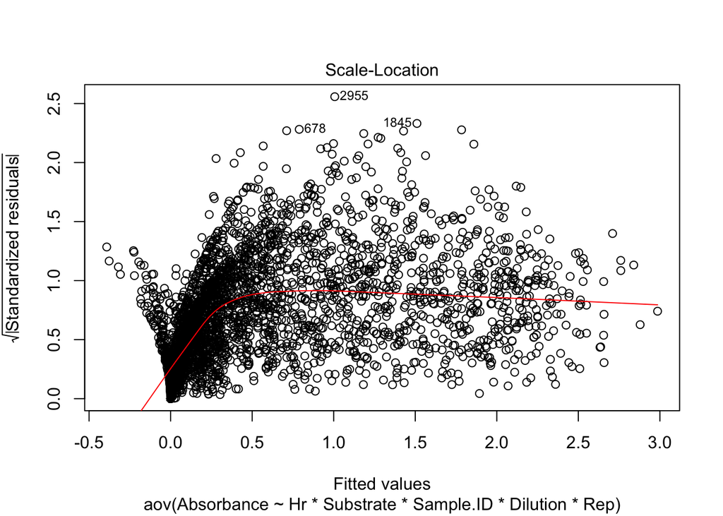

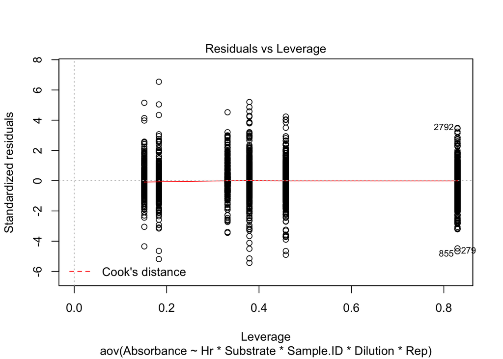

```r
plot(mod2_aov_biologTidy)
```

```r
mod3_aov_biologTidy<-aov(Absorbance~Hr*Substrate*Sample.ID*Dilution,data=biologTidy)
summary.aov(mod3_aov_biologTidy)
```

```
##                                   Df Sum Sq Mean Sq  F value   Pr(>F)
## Hr                                 2  332.8  166.40 1103.966  < 2e-16 ***
## Substrate                         31  143.0    4.61   30.607  < 2e-16 ***
## Sample.ID                          3  244.0   81.34  539.661  < 2e-16 ***
## Dilution                           1    4.7    4.65   30.852 3.06e-08 ***
## Hr:Substrate                      62   71.8    1.16    7.682  < 2e-16 ***
## Hr:Sample.ID                       6   72.9   12.15   80.636  < 2e-16 ***
## Substrate:Sample.ID               93   66.1    0.71    4.718  < 2e-16 ***
## Hr:Dilution                        2    4.0    1.98   13.163 2.05e-06 ***
## Substrate:Dilution                31   13.4    0.43    2.877 2.16e-07 ***
## Sample.ID:Dilution                 3  100.2   33.41  221.665  < 2e-16 ***
## Hr:Substrate:Sample.ID           186   59.3    0.32    2.116 2.25e-15 ***
## Hr:Substrate:Dilution             62   14.8    0.24    1.584  0.00266 **
## Hr:Sample.ID:Dilution              6   60.2   10.03   66.565  < 2e-16 ***
## Substrate:Sample.ID:Dilution      93   49.9    0.54    3.557  < 2e-16 ***
## Hr:Substrate:Sample.ID:Dilution  186   33.5    0.18    1.193  0.04267 *
## Residuals                       2688  405.2    0.15
## ---
## Signif. codes:  0 '***' 0.001 '**' 0.01 '*' 0.05 '.' 0.1 ' ' 1
```

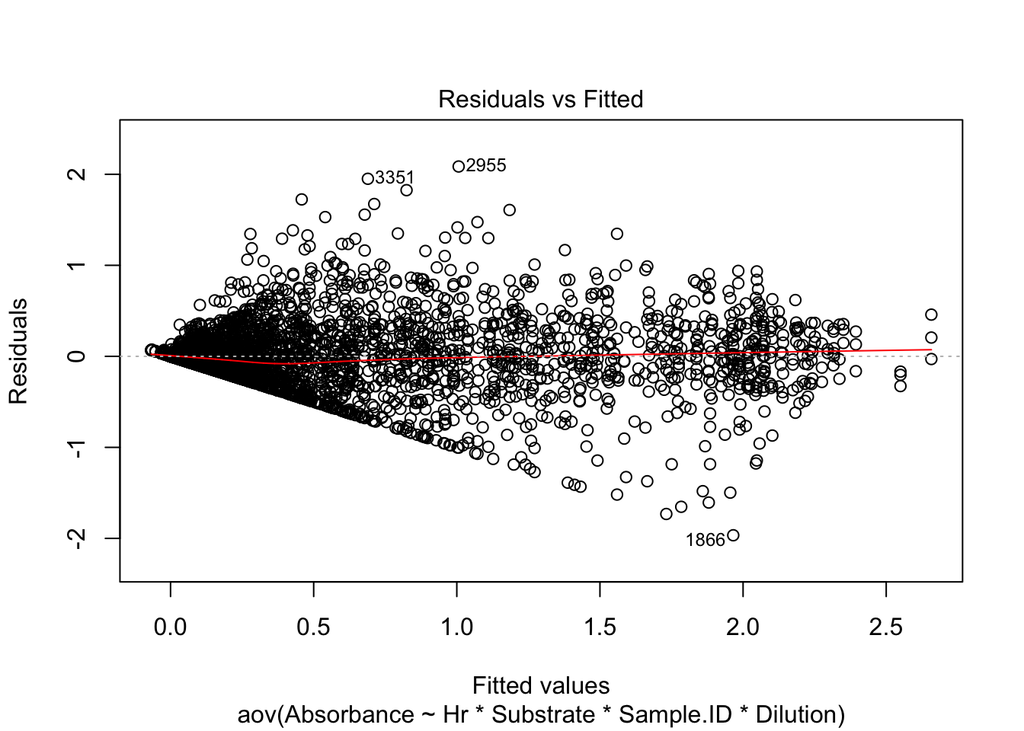

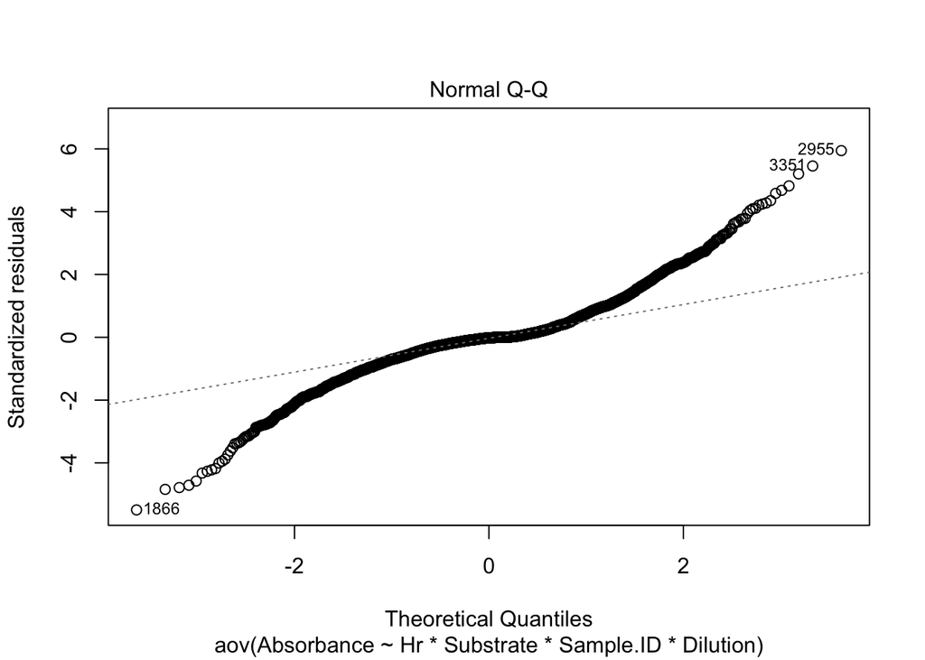

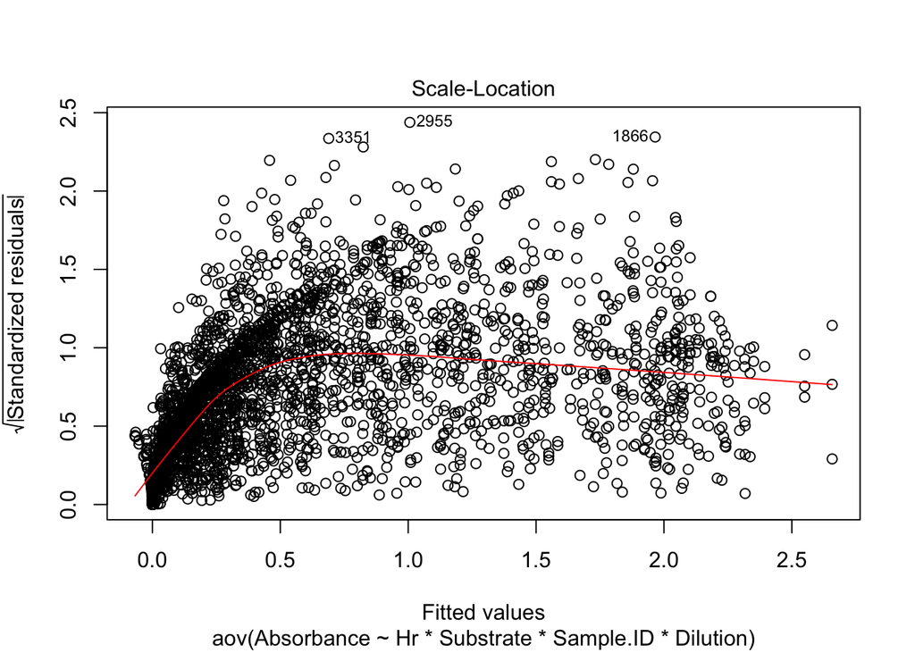

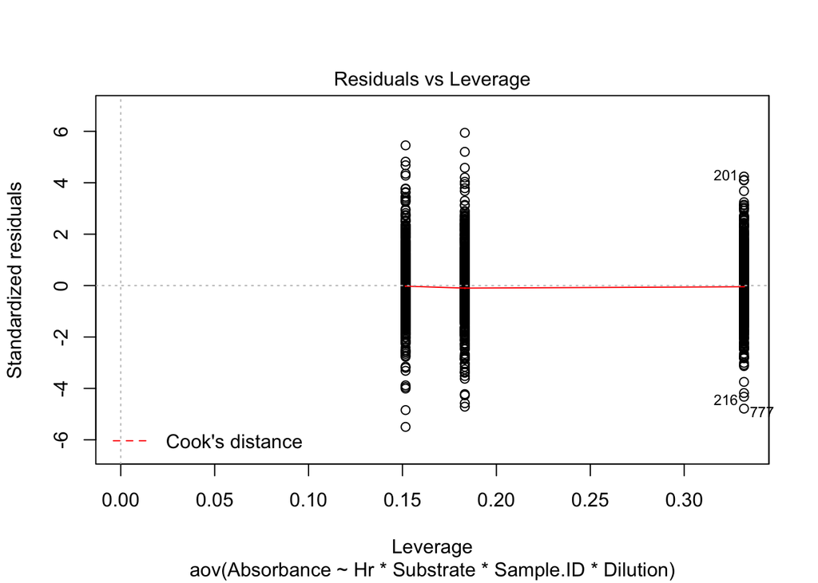

```r
plot(mod3_aov_biologTidy)
```

(B.) by location and dilution:

```r
biologClearCreekVeryDilute%>% filter()%>%mutate()
```

```
## # A tibble: 288 x 6
##      Rep Well  Substrate                   Absorbance_Sum Hr    Absorbance
##    <int> <fct> <fct>                                <dbl> <chr>      <dbl>
##  1     1 A1    Water                                0     24         0
##  2     1 A1    Water                                0     48         0
##  3     1 A1    Water                                0     144        0
##  4     1 A2    β-Methyl-D- Glucoside                0.013 24         0.004
##  5     1 A2    β-Methyl-D- Glucoside                0.013 48         0.005
##  6     1 A2    β-Methyl-D- Glucoside                0.013 144        0.004
##  7     1 A3    D-Galactonic Acid γ-Lactone          0.016 24         0.008
##  8     1 A3    D-Galactonic Acid γ-Lactone          0.016 48         0.007
##  9     1 A3    D-Galactonic Acid γ-Lactone          0.016 144        0.001
## 10     1 A4    L-Arginine                           0.005 24         0.003
## # … with 278 more rows
```

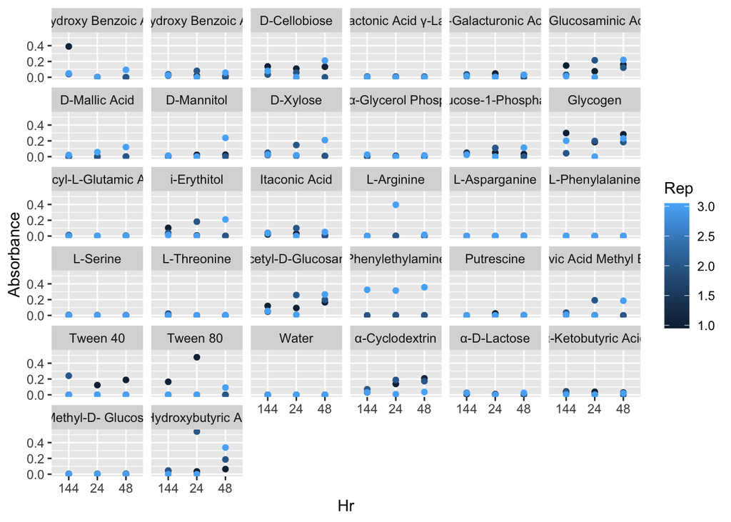

```r
biologClearCreekVeryDilute%>% ggplot(aes(x=Hr,y=Absorbance, color=Rep)) + geom_point()+facet_wrap(.~Substrate)+geom_smooth(method="lm")
```

[figure not shown]

```r
mod_biologClearCreekVeryDilute <- lm(Absorbance~Hr*Rep,data=biologClearCreek) ##What information might this provive? **overall treands at a given location to compare against eachother regardless of the dilution factor.
ggplot(mod_biologClearCreekVeryDilute,(aes(x=Hr,y=Absorbance)))+geom_smooth(method = lm)
```

```r
##x=hr y=absorbance color=repetion (for each locationDilution) and determine slope
```

##analyzing variation between sites and reps quanititively.

[output not shown]